# Course project for machine learning

Kristina Juhlin

20 November 2015

## Introduction

The aim of this project is to classify a number of performed exercises as correctly or incorrectly executed. If incorrectly executed, I will identify in which of four possible ways they are faulting.

## Data

This project uses the weightlifting exercise data set collected by [Vellosso et al](http://groupware.les.inf.puc-rio.br/work.jsf?p1=11201) which includes measurements of arm, forearm, hip and dumbbell movements while performing a weightlifting exercise. The exercises are classified as correctly (class A) performed or wrongly performed in one of the following ways: throwing the elbows to the front (class B), lifting the dumbbell only halfway (class C), lowering the dumbbell only halfway (class D) and throwing the hips to the front (class E).

```r
library(caret)
library(plyr)
library(dplyr)
library(gridExtra)
library(doParallel)
library(gbm)
library(randomForest)
library(foreach)
library(knitr)
library(gridExtra)
```

```r
if (!file.exists("pml-training.csv")){
download.file("https://d396qusza40orc.cloudfront.net/predmachlearn/pml-training.csv","pml-training.csv")
}
pml_data<- read.csv("pml-training.csv", header = TRUE, na.strings = c("","NA"))

levels(pml_data$classe)<-c("Correct", "ElbowsFront", "LiftHalf", "LowHalf", "HipsFront")
```

## Creating the predictive model

### Test and training set

I divided the 19622 samples into a training set (60% of samples) and a testing set (40% of samples). Exploratory analysis was then performed on the samples in the training set.

```r
# Divide data into training and testing set
set.seed(1000)
inTrain = createDataPartition(pml_data$classe, p = 0.6)[[1]]

training = pml_data[ inTrain,]
testing  = pml_data[-inTrain,]
```

### Exploratory analysis

I start by looking at the column names and values of the training set. I then look at the number of exercises per class and the number of time windows per performed exercise. I find that there are around 15 time windows on average for each performed exercise.

```r
names(training)
summary(training)
str(training)
```

```r
# Number of time windows for each participant and event type
t <- count(training, num_window, classe, user_name);

# Number of new windows for each user and classe
t2 <- training %>% filter(new_window=="yes") %>% count(classe, user_name);

g1<-ggplot(data=t2, aes(x=classe,y=n, fill=classe))+geom_boxplot()+geom_point()+
    theme(axis.text.x = element_text(angle = 45, hjust = 1))+
    ggtitle("Excercises per class")
g2<-ggplot(data=t, aes(x=classe,y=n, fill=classe))+geom_boxplot()+geom_jitter()+
    theme(axis.text.x = element_text(angle = 45, hjust = 1))+
    ggtitle("Windows per excercise")

#grid.arrange(g1,g2, nrow=1)
```

For this project, I will consider all measurements as independent ‘snapshots in time’ and not take the time stamps into account. Therefore I exclude the columns with time stamp information when building my model. I also remove the column containing the user name and the row id.

```r
# exclude user name and time window columns
removeColumns <- function(data){
    data <- data[,-grep("timestamp",names(data))]
    data <- data[,-grep("window",names(data))]
    data <- data[,-grep("user_name",names(data))]
    data <- data[,-grep("X",names(data))]
}
training <- removeColumns(training)

# Store classe in separate variable
training.class <- training$classe
training$classe<-NULL;
```

There is a large number of missing values for many of the columns. After investigating this I find that the missing values occur for all time windows that are not marked as ‘new’. Further investigation shows that the columns contain missing values are those that would be collected only ones per exercise, such as the mean or standard deviation of the measurements of a certain variable for the performed exercise. Since the timing will not be taken into account these columns are removed.

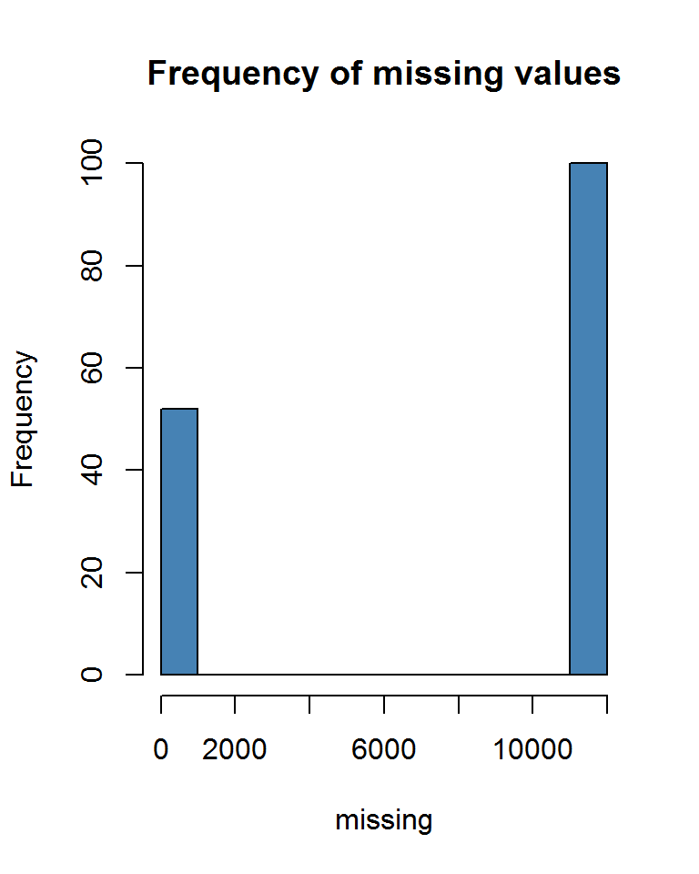

```r
# Identify missing values
missing <- apply(training, 2, function(x) sum(is.na(x)));
hist(missing, col="steelblue", main="Frequency of missing values")
```

```r
# either no missing or almost all missing => no point in imputing values
names(training[,missing>0])
```

```
##   [1] "kurtosis_roll_belt"       "kurtosis_picth_belt"
##   [3] "kurtosis_yaw_belt"        "skewness_roll_belt"
##   [5] "skewness_roll_belt.1"     "skewness_yaw_belt"
##   [7] "max_roll_belt"            "max_picth_belt"
##   [9] "max_yaw_belt"             "min_roll_belt"
##  [11] "min_pitch_belt"           "min_yaw_belt"
##  [13] "amplitude_roll_belt"      "amplitude_pitch_belt"
##  [15] "amplitude_yaw_belt"       "var_total_accel_belt"
##  [17] "avg_roll_belt"            "stddev_roll_belt"
##  [19] "var_roll_belt"            "avg_pitch_belt"
##  [21] "stddev_pitch_belt"        "var_pitch_belt"
##  [23] "avg_yaw_belt"             "stddev_yaw_belt"
##  [25] "var_yaw_belt"             "var_accel_arm"
##  [27] "avg_roll_arm"             "stddev_roll_arm"
##  [29] "var_roll_arm"             "avg_pitch_arm"
```

[output cut: 35 more lines]

```r
# remove columns with NAs
training<- training[,missing==0];
```

Now that all non-numeric variables and columns with NAs are removed I compute the correlation between the remaining variables. For highly correlated variables it is generally better to include only one in the model since they contain more or less the same information. I identify and exclude variables with an absolute value of the correlation of more than 0.9.

```r
# Check correlation between all numeric variables
numerics <- sapply(training, is.numeric)
correlationMatrix <- cor(training[,numerics])
correlated <- findCorrelation(correlationMatrix, cutoff=0.9)

# correlated columns
names(training[,correlated])
```

```
## [1] "accel_belt_z"     "roll_belt"        "accel_belt_y"
## [4] "accel_belt_x"     "gyros_dumbbell_x" "gyros_dumbbell_z"
## [7] "gyros_arm_x"
```

```r
# delete feature with correlation>0.9
# they provide little extra information and slow down model making
training <- training[,-correlated];

# turn all remaining variables of training into numeric (prevents later errors in prediction function)
training<-sapply(training,as.numeric);
```

The training data is now fully processed, let’s process the testing data in the same way. I will remove columns with user name and time stamp information, and columns with missing values and correlated variables (based on column names identified from training data).

```r
# Transform test data in same way as training data
testing.class <- testing$classe
testing$classe<-NULL;
testing <- removeColumns(testing)
testing <- testing[,missing==0];
testing <- testing[,-correlated]
testing<-sapply(testing,as.numeric);
```

## Fitting the model

I use the training data to fit a number of models and measure their in-sample error rates. Based on this I will select a smaller number of well-performing models and use the test data set to estimate their out-of-sample error.

### Algorithm type

I choose to fit two types of models, one random forest model and one gradient boosting machine (GBM) model. First, I fit four models, one GBM with standard parameters, one GBM with scaling of variables, one GBM using PCA preprocessing and one random forest model with standard parameters. For all models I use five-fold cross validation for training and estimating the accuracy. I then compare the models to find the ones that gives the highest accuracy. The results for these four models can be found in tables 1-4.

```r
# fit standard gbm models
# use multiple cores
registerDoParallel(cores=2)

# Use 5-fold cross validation instead of boosting to save time and prevent bias
fit_pca    <- train(training,training.class, method="gbm",
                 trControl = trainControl(method = "cv", number = 5),
                 preProcess = "pca",
                 verbose=FALSE)
fit_org<- train(training, training.class, method="gbm",
                 trControl = trainControl(method = "cv", number = 5),
                 verbose=FALSE)
fit_scale<- train(training, training.class, method="gbm",
                  trControl = trainControl(method = "cv", number = 5),
                  preProcess = c("center","scale"),
                  verbose=FALSE)

fit_rf <- train(training, training.class, method="rf",
                trControl = trainControl(method = "cv", number = 5))

# Look at insample accuraccy
kable(fit_org$results, caption="Table 1: GBM model with standard parameters")
```

Table 1: GBM model with standard parameters

|  | shrinkage | interaction.depth | n.minobsinnode | n.trees | Accuracy | Kappa | AccuracySD | KappaSD |
| --- | --- | --- | --- | --- | --- | --- | --- | --- |
| 1 | 0.1 | 1 | 10 | 50 | 0.7398132 | 0.6705396 | 0.0086525 | 0.0109160 |
| 4 | 0.1 | 2 | 10 | 50 | 0.8498654 | 0.8098518 | 0.0061774 | 0.0077529 |
| 7 | 0.1 | 3 | 10 | 50 | 0.8924955 | 0.8639241 | 0.0087181 | 0.0110943 |
| 2 | 0.1 | 1 | 10 | 100 | 0.8105487 | 0.7603543 | 0.0059295 | 0.0074731 |
| 5 | 0.1 | 2 | 10 | 100 | 0.9027703 | 0.8769453 | 0.0078366 | 0.0099608 |
| 8 | 0.1 | 3 | 10 | 100 | 0.9380967 | 0.9216637 | 0.0059730 | 0.0075588 |
| 3 | 0.1 | 1 | 10 | 150 | 0.8435824 | 0.8021923 | 0.0075500 | 0.0095640 |
| 6 | 0.1 | 2 | 10 | 150 | 0.9268868 | 0.9074874 | 0.0045477 | 0.0057581 |
| 9 | 0.1 | 3 | 10 | 150 | 0.9583064 | 0.9472538 | 0.0038200 | 0.0048294 |

```r
kable(fit_pca$results, caption="Table 2: GBM model using principal components")
```

Table 2: GBM model using principal components

|  | shrinkage | interaction.depth | n.minobsinnode | n.trees | Accuracy | Kappa | AccuracySD | KappaSD |
| --- | --- | --- | --- | --- | --- | --- | --- | --- |
| 1 | 0.1 | 1 | 10 | 50 | 0.5716723 | 0.4504316 | 0.0088953 | 0.0115314 |
| 4 | 0.1 | 2 | 10 | 50 | 0.6556547 | 0.5616460 | 0.0055000 | 0.0066730 |
| 7 | 0.1 | 3 | 10 | 50 | 0.7093233 | 0.6311142 | 0.0073320 | 0.0095887 |
| 2 | 0.1 | 1 | 10 | 100 | 0.6246596 | 0.5214996 | 0.0116850 | 0.0147871 |
| 5 | 0.1 | 2 | 10 | 100 | 0.7201085 | 0.6448235 | 0.0097592 | 0.0124325 |
| 8 | 0.1 | 3 | 10 | 100 | 0.7686815 | 0.7067202 | 0.0064861 | 0.0083092 |
| 3 | 0.1 | 1 | 10 | 150 | 0.6495414 | 0.5543182 | 0.0108415 | 0.0137735 |
| 6 | 0.1 | 2 | 10 | 150 | 0.7527165 | 0.6864082 | 0.0108672 | 0.0138782 |
| 9 | 0.1 | 3 | 10 | 150 | 0.8046868 | 0.7525086 | 0.0082535 | 0.0105424 |

```r
kable(fit_scale$results, caption="Table 3: GBM model using scaling")
```

Table 3: GBM model using scaling

|  | shrinkage | interaction.depth | n.minobsinnode | n.trees | Accuracy | Kappa | AccuracySD | KappaSD |
| --- | --- | --- | --- | --- | --- | --- | --- | --- |
| 1 | 0.1 | 1 | 10 | 50 | 0.7399813 | 0.6705946 | 0.0091509 | 0.0113425 |
| 4 | 0.1 | 2 | 10 | 50 | 0.8481665 | 0.8076887 | 0.0075275 | 0.0095615 |
| 7 | 0.1 | 3 | 10 | 50 | 0.8899457 | 0.8606473 | 0.0052101 | 0.0066388 |
| 2 | 0.1 | 1 | 10 | 100 | 0.8096143 | 0.7591440 | 0.0068075 | 0.0085672 |
| 5 | 0.1 | 2 | 10 | 100 | 0.9025987 | 0.8767087 | 0.0051743 | 0.0065748 |
| 8 | 0.1 | 3 | 10 | 100 | 0.9374994 | 0.9208909 | 0.0049914 | 0.0063480 |
| 3 | 0.1 | 1 | 10 | 150 | 0.8457887 | 0.8049372 | 0.0060699 | 0.0077206 |
| 6 | 0.1 | 2 | 10 | 150 | 0.9256965 | 0.9059521 | 0.0062812 | 0.0079854 |
| 9 | 0.1 | 3 | 10 | 150 | 0.9576251 | 0.9463850 | 0.0060662 | 0.0076704 |

```r
kable(fit_rf$results, caption="Table 4: Random forest model with standard parameters")
```

Table 4: Random forest model with standard parameters

| mtry | Accuracy | Kappa | AccuracySD | KappaSD |
| --- | --- | --- | --- | --- |
| 2 | 0.9881116 | 0.9849591 | 0.0018500 | 0.0023421 |
| 23 | 0.9897249 | 0.9870015 | 0.0017086 | 0.0021605 |
| 45 | 0.9859039 | 0.9821671 | 0.0014164 | 0.0017925 |

For some reason, using PCA preprocessing makes the model perform significantly worse. Scaling the columns values before modeling makes no difference on the result compared to using original values. The random forest model performs really well with an accuracy of 99%. The standard GBM with 150 trees and interaction depth of three has an accuracy of 96%. I will see if I can improve this by tuning the following GBM parameters:  
- Interaction depth  
- Number of trees  
- Shrinkage  
- Minimum number of cases in end nodes

```r
# Fit several random tree models using different input parameters, use cross valdiation to determine quality of models

# 1. How many trees do I need to fit?
gbmGrid <-  expand.grid(interaction.depth = 3,
                        n.trees = c(100,200,300,400,500),
                        shrinkage = 0.1,
                        n.minobsinnode = 10)

fit_nTrees<- train(training, training.class,
                 method="gbm",
                 trControl = trainControl(method = "cv", number = 5),
                 tuneGrid = gbmGrid,
                 verbose=FALSE)
```

```r
# 2. What is the most appropriate interaction depth?
gbmGrid <-  expand.grid(interaction.depth = c(1,2,3,4,5),
                        n.trees = c(200),
                        shrinkage = 0.1,
                        n.minobsinnode = 10)

fit_depth<- train(training, training.class,
                 method="gbm",
                 trControl = trainControl(method = "cv", number = 5),
                 tuneGrid = gbmGrid,
                 verbose=FALSE)
```

```r
# 3. Best value for shrinkage?
gbmGrid <-  expand.grid(interaction.depth = 3,
                        n.trees = 200,
                        shrinkage = c(0.25, 0.1, 0.05),
                        n.minobsinnode = 10)

fit_shrink<- train(training, training.class,
                 method="gbm",
                 trControl = trainControl(method = "cv", number = 5),
                 tuneGrid = gbmGrid,
                 verbose=FALSE)
```

```r
# 4. Minimum node size: 10
gbmGrid <-  expand.grid(interaction.depth = 3,
                        n.trees = 200,
                        shrinkage = c(0.1),
                        n.minobsinnode = c(5,10,20))

fit_node<- train(training, training.class,
                 method="gbm",
                 trControl = trainControl(method = "cv", number = 5),
                 tuneGrid = gbmGrid,
                 verbose=FALSE)
```

Plotting the accuracy as a function of the tuned parameters leads me to choose a final GBM model with shrinkage = 0.25, 500 trees, interaction depth = 5 and minimum node size of 10. This model has an in-sample accuracy of 99.2%.

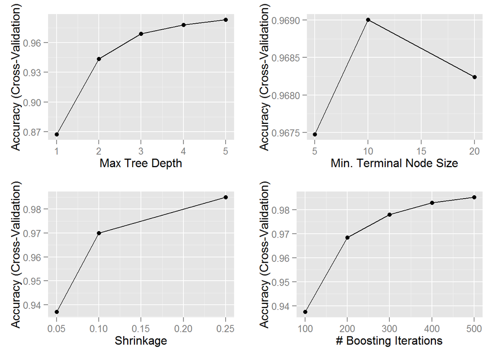

```r
# Plot results from all fits
g1 <- ggplot(fit_depth)
g2 <- ggplot(fit_node)
g3 <- ggplot(fit_shrink )
g4 <- ggplot(fit_nTrees)
library(gridExtra)

grid.arrange(g1,g2,g3,g4)
```

```r
# 5. Final model
gbmGrid <-  expand.grid(interaction.depth = 5,
                        n.trees = 500,
                        shrinkage = 0.25,
                        n.minobsinnode = 10)

fit_gmb_final<- train(training, training.class,
                 method="gbm",
                 trControl = trainControl(method = "cv", number = 5),
                 verbose=FALSE,
                 tuneGrid = gbmGrid)

kable(fit_gmb_final$results, caption="Table 5: GBM model after tuning")
```

Table 5: GBM model after tuning

| interaction.depth | n.trees | shrinkage | n.minobsinnode | Accuracy | Kappa | AccuracySD | KappaSD |
| --- | --- | --- | --- | --- | --- | --- | --- |
| 5 | 500 | 0.25 | 10 | 0.9921872 | 0.9901181 | 0.0018184 | 0.0022999 |

```r
kable(fit_rf$results, caption = "Table 6: Random forest model performance")
```

Table 6: Random forest model performance

| mtry | Accuracy | Kappa | AccuracySD | KappaSD |
| --- | --- | --- | --- | --- |
| 2 | 0.9881116 | 0.9849591 | 0.0018500 | 0.0023421 |
| 23 | 0.9897249 | 0.9870015 | 0.0017086 | 0.0021605 |
| 45 | 0.9859039 | 0.9821671 | 0.0014164 | 0.0017925 |

```r
# Test both models on test dataset
pred_gbm <- predict(fit_gmb_final, newdata=testing)
pred_rf  <- predict(fit_rf, newdata=testing)

kable(confusionMatrix(pred_gbm, testing.class)$table)
```

|  | Correct | ElbowsFront | LiftHalf | LowHalf | HipsFront |
| --- | --- | --- | --- | --- | --- |
| Correct | 2229 | 15 | 0 | 0 | 0 |
| ElbowsFront | 3 | 1495 | 4 | 0 | 1 |
| LiftHalf | 0 | 7 | 1361 | 16 | 0 |
| LowHalf | 0 | 1 | 3 | 1268 | 7 |
| HipsFront | 0 | 0 | 0 | 2 | 1434 |

```r
confusionMatrix(pred_gbm, testing.class)$overall[1]
```

```
##  Accuracy
## 0.9924802
```

```r
kable(confusionMatrix(pred_rf, testing.class)$table)
```

|  | Correct | ElbowsFront | LiftHalf | LowHalf | HipsFront |
| --- | --- | --- | --- | --- | --- |
| Correct | 2226 | 23 | 0 | 0 | 0 |
| ElbowsFront | 3 | 1489 | 10 | 0 | 0 |
| LiftHalf | 0 | 6 | 1354 | 25 | 1 |
| LowHalf | 1 | 0 | 4 | 1261 | 1 |
| HipsFront | 2 | 0 | 0 | 0 | 1440 |

```r
confusionMatrix(pred_rf, testing.class)$overall[1]
```

```
##  Accuracy
## 0.9903135
```

## Selecting final model

The tuned GBM model has slightly higher accuracy (estimated from the cross validation) than the random forest model.

I then test both the GBM model and the random forest model against my testing data set to estimate the out-of-sample error. The estimated out of sample error (calculated as 1-accuracy) is 0.01 for the random forest model and 0.008 for the GBM model. Based on this I expect my model to perform well against the final 20 test cases.

## Applying to test cases

Lastly, the selected GBM method is applied to the 20 test cases provided for the course submission. The model manages to successfully predict all 20 cases.

```r
if (!file.exists("pml-training.csv")){
download.file("https://d396qusza40orc.cloudfront.net/predmachlearn/pml-testing.csv","pml-testing.csv")
}
tests<- read.csv("pml-testing.csv", header = TRUE, na.strings = c("","NA"))
tests.id <- tests$problem_id;
tests$problem_id <- NULL;

tests <- removeColumns(tests)
tests <- tests[,missing==0]
tests <- tests[,-correlated]
tests <- sapply(tests,as.numeric);

pred_submission<- predict(fit_gmb_final, newdata=tests)
levels(pred_submission)<- c("A", "B", "C", "D", "E")
```

```r
pml_write_files = function(x){
  n = length(x)
  for(i in 1:n){
    filename = paste0("problem_id_",i,".txt")
    write.table(x[i],file=filename,quote=FALSE,row.names=FALSE,col.names=FALSE)
  }
}

pml_write_files(pred_submission)
```